# Linear Regression

Build a model describing relationship between `miles per gallon(mpg)` with other independant variables

```python
import numpy as np
import pandas as pd
import matplotlib.pyplot as plt
import seaborn as sns
%matplotlib inline
from sklearn.linear_model import LinearRegression
from sklearn.model_selection import train_test_split # to split data randomly between training and testing data
```

```python
car_data = pd.read_csv('C://Users/syeda/Downloads/auto-mpg.csv')
```

```python
# 8 variables:
#
# MPG (miles per gallon),
# cylinders,
# engine displacement (cu. inches),
# horsepower,
# vehicle weight (lbs.),
# time to accelerate from O to 60 mph (sec.),
# model year (modulo 100), and
# origin of car (1. American, 2. European,3. Japanese).
#
# Also provided are the car labels (types)
# Missing data values are marked by series of question marks.
car_data.head()
```

|  | mpg | cylinders | displacement | horsepower | weight | acceleration | model year | origin | car name |
| --- | --- | --- | --- | --- | --- | --- | --- | --- | --- |
| 0 | 18.0 | 8 | 307.0 | 130 | 3504 | 12.0 | 70 | 1 | chevrolet chevelle malibu |
| 1 | 15.0 | 8 | 350.0 | 165 | 3693 | 11.5 | 70 | 1 | buick skylark 320 |
| 2 | 18.0 | 8 | 318.0 | 150 | 3436 | 11.0 | 70 | 1 | plymouth satellite |
| 3 | 16.0 | 8 | 304.0 | 150 | 3433 | 12.0 | 70 | 1 | amc rebel sst |
| 4 | 17.0 | 8 | 302.0 | 140 | 3449 | 10.5 | 70 | 1 | ford torino |

```python
car_data.shape
```

```
(398, 9)
```

```python
# this column is really not necessary for the analysis here
car_data.drop(columns='car name',inplace=True,axis=1)
```

```python
# just to be sure about the categorical variable
car_data['origin'].replace({1:'america',2:'europe',3:'asia'},inplace=True)
```

```python
car_data.head()
```

|  | mpg | cylinders | displacement | horsepower | weight | acceleration | model year | origin |
| --- | --- | --- | --- | --- | --- | --- | --- | --- |
| 0 | 18.0 | 8 | 307.0 | 130 | 3504 | 12.0 | 70 | america |
| 1 | 15.0 | 8 | 350.0 | 165 | 3693 | 11.5 | 70 | america |
| 2 | 18.0 | 8 | 318.0 | 150 | 3436 | 11.0 | 70 | america |
| 3 | 16.0 | 8 | 304.0 | 150 | 3433 | 12.0 | 70 | america |
| 4 | 17.0 | 8 | 302.0 | 140 | 3449 | 10.5 | 70 | america |

#### Create Dummy Variables

Values like 'america' cannot be read into an equation. Using substitutes like 1 for america, 2 for europe and 3 for asia would end up implying that european cars fall exactly half way between american and asian cars! we dont want to impose such an baseless assumption!

So we create 3 simple true or false columns with titles equivalent to "Is this car America?", "Is this care European?" and "Is this car Asian?". These will be used as independent variables without imposing any kind of ordering between the three regions.

```python
# dummy variables - One_hot Encoding
car_data = pd.get_dummies(data= car_data, columns=['origin'])
car_data.head()
# splits n categorical variable values into n columns, but we can use n-1 columns, because we can know the state of all
```

|  | mpg | cylinders | displacement | horsepower | weight | acceleration | model year | origin_america | origin_asia | origin_europe |
| --- | --- | --- | --- | --- | --- | --- | --- | --- | --- | --- |
| 0 | 18.0 | 8 | 307.0 | 130 | 3504 | 12.0 | 70 | 1 | 0 | 0 |
| 1 | 15.0 | 8 | 350.0 | 165 | 3693 | 11.5 | 70 | 1 | 0 | 0 |
| 2 | 18.0 | 8 | 318.0 | 150 | 3436 | 11.0 | 70 | 1 | 0 | 0 |
| 3 | 16.0 | 8 | 304.0 | 150 | 3433 | 12.0 | 70 | 1 | 0 | 0 |
| 4 | 17.0 | 8 | 302.0 | 140 | 3449 | 10.5 | 70 | 1 | 0 | 0 |

#### Dealing With Missing Values

```python
car_data.describe(include='all')
# from here we can see that `horsepower` seems to be a numerical value but doesn't have statistics,
# so this may be due to the data type being `object` or have missing or unexpected values.
```

|  | mpg | cylinders | displacement | horsepower | weight | acceleration | model year | origin_america | origin_asia | origin_europe |
| --- | --- | --- | --- | --- | --- | --- | --- | --- | --- | --- |
| count | 398.000000 | 398.000000 | 398.000000 | 398 | 398.000000 | 398.000000 | 398.000000 | 398.000000 | 398.000000 | 398.000000 |
| unique | NaN | NaN | NaN | 94 | NaN | NaN | NaN | NaN | NaN | NaN |
| top | NaN | NaN | NaN | 150 | NaN | NaN | NaN | NaN | NaN | NaN |
| freq | NaN | NaN | NaN | 22 | NaN | NaN | NaN | NaN | NaN | NaN |
| mean | 23.514573 | 5.454774 | 193.425879 | NaN | 2970.424623 | 15.568090 | 76.010050 | 0.625628 | 0.198492 | 0.175879 |
| std | 7.815984 | 1.701004 | 104.269838 | NaN | 846.841774 | 2.757689 | 3.697627 | 0.484569 | 0.399367 | 0.381197 |
| min | 9.000000 | 3.000000 | 68.000000 | NaN | 1613.000000 | 8.000000 | 70.000000 | 0.000000 | 0.000000 | 0.000000 |
| 25% | 17.500000 | 4.000000 | 104.250000 | NaN | 2223.750000 | 13.825000 | 73.000000 | 0.000000 | 0.000000 | 0.000000 |
| 50% | 23.000000 | 4.000000 | 148.500000 | NaN | 2803.500000 | 15.500000 | 76.000000 | 1.000000 | 0.000000 | 0.000000 |
| 75% | 29.000000 | 8.000000 | 262.000000 | NaN | 3608.000000 | 17.175000 | 79.000000 | 1.000000 | 0.000000 | 0.000000 |
| max | 46.600000 | 8.000000 | 455.000000 | NaN | 5140.000000 | 24.800000 | 82.000000 | 1.000000 | 1.000000 | 1.000000 |

```python
car_data.dtypes
# horsepower is object, may be due to the unexpected values
```

```
mpg               float64
cylinders           int64
displacement      float64
horsepower         object
weight              int64
acceleration      float64
model year          int64
origin_america      uint8
origin_asia         uint8
origin_europe       uint8
dtype: object
```

```python
is_hp_digit = car_data['horsepower'].str.isdigit() # to get a series of digit True/False
car_data[ is_hp_digit == False] # to see which character makes horsepower object
```

|  | mpg | cylinders | displacement | horsepower | weight | acceleration | model year | origin_america | origin_asia | origin_europe |
| --- | --- | --- | --- | --- | --- | --- | --- | --- | --- | --- |
| 32 | 25.0 | 4 | 98.0 | ? | 2046 | 19.0 | 71 | 1 | 0 | 0 |
| 126 | 21.0 | 6 | 200.0 | ? | 2875 | 17.0 | 74 | 1 | 0 | 0 |
| 330 | 40.9 | 4 | 85.0 | ? | 1835 | 17.3 | 80 | 0 | 0 | 1 |
| 336 | 23.6 | 4 | 140.0 | ? | 2905 | 14.3 | 80 | 1 | 0 | 0 |
| 354 | 34.5 | 4 | 100.0 | ? | 2320 | 15.8 | 81 | 0 | 0 | 1 |
| 374 | 23.0 | 4 | 151.0 | ? | 3035 | 20.5 | 82 | 1 | 0 | 0 |

```python
car_data['horsepower'].replace({'?':np.nan},inplace=True)
```

```python
car_data[ is_hp_digit == False] # to check if the values are replaced
```

|  | mpg | cylinders | displacement | horsepower | weight | acceleration | model year | origin_america | origin_asia | origin_europe |
| --- | --- | --- | --- | --- | --- | --- | --- | --- | --- | --- |
| 32 | 25.0 | 4 | 98.0 | NaN | 2046 | 19.0 | 71 | 1 | 0 | 0 |
| 126 | 21.0 | 6 | 200.0 | NaN | 2875 | 17.0 | 74 | 1 | 0 | 0 |
| 330 | 40.9 | 4 | 85.0 | NaN | 1835 | 17.3 | 80 | 0 | 0 | 1 |
| 336 | 23.6 | 4 | 140.0 | NaN | 2905 | 14.3 | 80 | 1 | 0 | 0 |
| 354 | 34.5 | 4 | 100.0 | NaN | 2320 | 15.8 | 81 | 0 | 0 | 1 |
| 374 | 23.0 | 4 | 151.0 | NaN | 3035 | 20.5 | 82 | 1 | 0 | 0 |

There are various ways to handle missing values. Drop the rows, replace missing values with median values etc. of the 398 rows 6 have NAN in the hp column. We could drop those 6 rows - which might not be a good idea under all situations

```python
#instead of dropping the rows, lets replace the missing values with median value.
car_data.median()
```

```
mpg                 23.0
cylinders            4.0
displacement       148.5
horsepower          93.5
weight            2803.5
acceleration        15.5
model year          76.0
origin_america       1.0
origin_asia          0.0
origin_europe        0.0
dtype: float64
```

```python
car_data['horsepower'].replace({np.nan:car_data['horsepower'].median()},inplace=True)
```

```python
car_data[ is_hp_digit == False] # to check if the values are replaced
```

|  | mpg | cylinders | displacement | horsepower | weight | acceleration | model year | origin_america | origin_asia | origin_europe |
| --- | --- | --- | --- | --- | --- | --- | --- | --- | --- | --- |
| 32 | 25.0 | 4 | 98.0 | 93.5 | 2046 | 19.0 | 71 | 1 | 0 | 0 |
| 126 | 21.0 | 6 | 200.0 | 93.5 | 2875 | 17.0 | 74 | 1 | 0 | 0 |
| 330 | 40.9 | 4 | 85.0 | 93.5 | 1835 | 17.3 | 80 | 0 | 0 | 1 |
| 336 | 23.6 | 4 | 140.0 | 93.5 | 2905 | 14.3 | 80 | 1 | 0 | 0 |
| 354 | 34.5 | 4 | 100.0 | 93.5 | 2320 | 15.8 | 81 | 0 | 0 | 1 |
| 374 | 23.0 | 4 | 151.0 | 93.5 | 3035 | 20.5 | 82 | 1 | 0 | 0 |

```python
# covert type to float
car_data['horsepower'] = car_data['horsepower'].astype('float64')
```

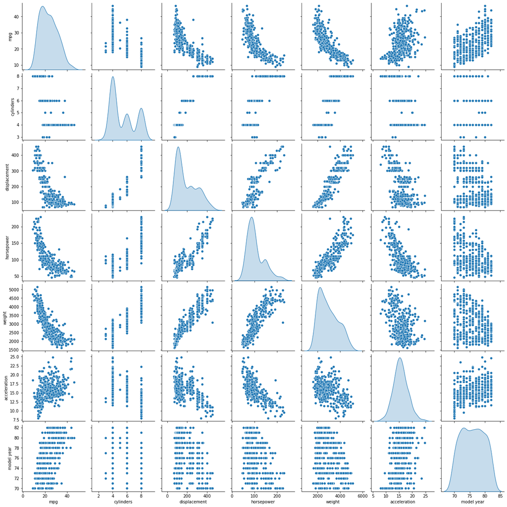

```python
sns.pairplot(data=car_data.iloc[:,0:7],diag_kind='kde')
plt.show()
```

Observation between 'mpg' and other attributes indicate the relationship is not really linear. However, the plots also indicate that linearity would still capture quite a bit of useful information/pattern.

#### Split Data

```python
# drop the dependant variable and also the nth dummy variable

#independant variables
X = car_data.drop(columns=['mpg','origin_europe'],axis=1)

#dependant variable
y = car_data[['mpg']]
```

```python
# split data into training and test data in 70:30 ratio
X_train,X_test,y_train,y_test = train_test_split(X, y, test_size=0.30,random_state=1)
```

#### Fit Linear Model

```python
regression_model = LinearRegression()
regression_model.fit(X_train,y_train)  # fit the linear regression model
```

```
LinearRegression()
```

```python
regression_model.coef_
```

```
array([[-0.39480797,  0.02894551, -0.02175221, -0.00735203,  0.06191937,
         0.83693389, -3.001283  , -0.60601796]])
```

```python
# coefficients of various independant variables
for indx, col_name in enumerate(X_train.columns):
    print(f'The Regression coefficient for {col_name} is {regression_model.coef_[0][indx]}')

# also the variables don't only influence mpg they influence each other too
```

```
The Regression coefficient for cylinders is -0.39480796616482017
The Regression coefficient for displacement is 0.028945510765487167
The Regression coefficient for horsepower is -0.02175220772354671
The Regression coefficient for weight is -0.007352032065147344
The Regression coefficient for acceleration is 0.06191936600761839
The Regression coefficient for model year is 0.8369338917644991
The Regression coefficient for origin_america is -3.0012830009185163
The Regression coefficient for origin_asia is -0.6060179643247368
```

```python
intercept = regression_model.intercept_[0]
print(f'The intercept is {intercept}')
```

```
The intercept is -18.283451116372103
```

```python
#so we can make an equation from above
```

```python
#R^2 for in-sample/training
regression_model.score(X_train,y_train)
# 81% of variance in y_train is explained by our model
```

```
0.8141025501610559
```

```python
#R^2 for out-sample/testing
regression_model.score(X_test,y_test)
# 84% of variance in y_test is explained by our model
```

```
0.8433135132808833
```

So R^2 is comparable, so seems it performed better and also didn't over-fit too much

Adding higher degree polynomials but only `interaction terms`, not X^2 kind but x*y terms

```python
from sklearn.preprocessing import PolynomialFeatures
```

```python
poly = PolynomialFeatures(degree=2,interaction_only=True) # degree 2 with only interaction terms
X_train2 = poly.fit_transform(X_train) # adding the variables
X_test2 = poly.fit_transform(X_test)
```

```python
print(X_train2.shape)
print(X_train.shape) # 29 variables increase
```

```
(278, 37)
(278, 8)
```

```python
poly_reg = LinearRegression()
poly_reg.fit(X_train2,y_train)
```

```
LinearRegression()
```

```python
#In-sample/Training will always increase with variables; maybe due to fluke correlation
poly_reg.score(X_train2,y_train)
```

```
0.9015975295006512
```

```python
# out-sample/testing
poly_reg.score(X_test2,y_test)
```

```
0.864744105908418
```

This 2% increase can be decide by ML engineer whether to take into account or he doesn't see it as very significant